# Microclimate of mire wetlands: testing the thermal buffer of groundwater in waterlogged and dry soils

Short title: testing the thermal buffer of mire groundwater

Eduardo Fernández-Pascual. Correspondence: Departamento de Biología de Organismos y Sistemas, Universidad de Oviedo; C/ Catedrático Rodrigo Uría, 33006 Oviedo/Uviéu, Spain; Tel.: +34985104787; email: efernandezpascual@gmail.com

12/05/2020

# 1 Introduction

Climate change (Ipcc 2014) affects global biodiversity from drylands (Huang et al. 2016) to forests (Seidl et al. 2017) and oceans (Hoegh-Guldberg et al. 2017). Ecosystems can be especially vulnerable when they meet certain criteria (Horsák et al. 2018): (a) preponderance of species that evolved under a cold climate; (b) low productivity due to nutrient limitation, making them sensitive to increased nutrient cycling caused by warming (Cornelissen et al. 2007); and (c) scatterred distribution pattern, which limits species dispersal and migration (Pearson and Dawson 2005). These characteristics are found in temperate peatlands such as mires, i.e. permanent semi-terrestrial wetlands where soils remain waterlogged but not inundated during most of the year (Wheeler and Proctor 2000). Mires are priority habitats for conservation that harbour high numbers of endangered species (Bergamini et al. 2009) and support highly-adapted floras in spatially-reduced areas (Grootjans et al. 2006). Habitat distribution models have predicted a loss of mire surface as a consequence of ongoing climate change (Essl et al. 2012).

Mires are however azonal habitats whose existence depends on local soil properties (Breckle 2002): by definition, they are areas with waterlogged soils. Grounwater can produce a buffer effect on soil temperature, keeping soils warmer than the air during cold periods, and vice versa (Ellenberg 1988; Geiger, Aron, and Todhunter 2009). Root-zone temperature is a major determinant of plant ecophysiology (Körner and Paulsen 2004), so the groundwater buffer effect is expected to allow mire plants to live along a wider range of air temperatures than they could otherwise. Indeed, mires have a relatively homogeneous flora despite being distributed from Mediterranean to Boreal biomes, and from low valleys to the alpine belt (Peterka et al. 2017). Recently, soil temperature measurements have become available for mires of North America (Raney, Fridley, and Leopold 2014), Western Europe (Fernandez-Pascual et al. 2015) and Central Europe (Horsák et al. 2018). Their comparison with air temperatures derived from models has shown that mire soils are indeed warmer in winter and cooler in summer, thus giving support to the existence of the groundwater thermal buffer (Fernandez-Pascual et al. 2015; Horsák et al. 2018). Furthermore, the effect has been linked to the composition of mire flora and fauna (Horsák et al. 2018; Schenková et al., n.d.), the growth rings of mire trees (Raney et al. 2016) and the role of mires as glacial refugia (Jiménez-Alfaro et al. 2016; Dítě et al. 2017).

It is evident that the groundwater buffer effect will play a determinant role in the response of mire habitats to climate change. As is the case for all azonal habitats, locally measured temperatures are essential to understand this response. Available data recorded temperatures only on the waterlogged soils, using model-derived air temperatures for comparison (Fernandez-Pascual et al. 2015; Horsák et al. 2018; Schenková et al., n.d.); or recorded temperatures in both wet and dry spots but for less than a year (Raney, Fridley, and Leopold 2014; Raney et al. 2016). This article provides the first measurement of the thermal buffer against surrounding non-mire areas, based on soil temperatures recorded during a period of five years. These measures are used to test the hypotheses that, when compared to adjacent dry soils, waterlogged mire soil are (i) warmer in winter and (ii) colder in summer; and have less thermal amplitude in (iii) daily and (iv) annual scales.

# 2 Materials and methods

This study took place in the temperate oceanic region of north-western Spain (43º N, 5º W). Local geography and climate are dominated by the Cantabrian Mountains (> 1500 m above sea level), which run parallel to the coast and trap the prevailing NW Atlantic winds. The resulting humid climate harbours the south-western limit of mire communities in Europe (Jiménez-Alfaro, Díaz González, and Fernández-Pascual 2011; Fernández Prieto, Fernández Ordóñez, and Collado Prieto 1985). Rain-fed raised bogs and acid valley mires can be found from the coast to just below the treeline, in poorly drained valleys and former glacial lakes. Glacial lakes undergoing silting develop transition mires and quaking bogs communities in the water-to-land transition. Spring fens appear in the mountains above 1000 m; they range from soft-water poor fens on acid bedrocks, to alkaline calcareous fens on limestone.

Some steps were taken to clean the logs. First, the records from the first week after installation were removed, to account for the own installation process and the settling of the soils. Second, and because some of the dataloggers had failed at different points in time, a selection was made for each site to keep only time series with records both for the dry and waterlogged points. Afterwards four bioclimatic variables were calculated for each datalogger:

- The mean diurnal range; i.e. the average for the whole period of the daily differences between the maximum and the minimum temperatures recorded in the day.
- The maximum temperature of the warmest month; i.e. the average of the daily maximum records, for the warmst month.
- The minimum temperature of the codlest month; i.e. the average of the daily minimum records, for the coldest month.
- The annual range; i.e. the difference between the maximum temperature of the warmest month and the minimum temperature of the coldest month.

To test if the differences between the dry and the waterlogged points of each site was significant, paired t-tests were used. Tests were one-tailed, according to the following hypotheses: the dry site would have a higher diurnal range, a higher maximum temperature, a lower minimum temperature, and a higher annual range.

# 3 Results

The dataloggers recorded temperatures for five years in five of the sites, four years in two, and two years in one (Fig. 6.1). A visual inspection of the time series shows more homogeneous temperatures in the waterlogged time series, which are almost always encompassed within the dry time series. The bioclimatic variables (Fig. 6.2) support this impression. The maximum temperatures of the warmest months are usually higher in the dry measuring points, by more than 6 ºC in some sites, both at low (El Molinucu, La Malva) and high (La Recoleta) elevations. The opposite is true for the minimums of the coldest months, in which case the temperature is generally colder in the dry points, although the difference is less pronounced than for the maximums. The mean diurnal range of temperatures is wider in the dry sites, as is annual temperature range; and again the effect is larger in the low sites and in La Recoleta. The t-tests supported the original hypotheses; namely waterlogged measuring points had (a) smaller diurnal fluctuactions (t = -3.05, p = 0.009, effect size = -2.29 ºC); (b) lower maximums (t = -3.04, p = 0.009, effect size = -4.28 ºC); (c) higher minimums (t = 2.86, p = 0.012, effect size = 0.77 ºC), and (d) smaller annual fluctuations (t = -3.95, p = 0.003, effect size = -5.05 ºC).

# 4 Discussion

The results presented here prove the existence of a thermal buffer effect in waterlogged mire soils, when compared with adjacent dry soils. The mire thermal buffer had been compared previously with air temperatures derived from models, with generally similar results (Fernandez-Pascual et al. 2015; Horsák et al. 2018). The mire buffer had also been compared to dry soils but only during the growing season (Raney, Fridley, and Leopold 2014; Raney et al. 2016); our results confirm those findings and extend them to the full year. Therefore, there exists a thermal buffer effect in mire soils that makes their temperatures less extreme than the surrounding landscape. This highlights the importance of using fine-scale microclimatic data to assess vegetation responses to climate change (Storlie et al. 2014).

One important difference with previous studies is the importance of the buffer during winter. The articles that had used model air temperatures as a control concluded that the buffer effect was stronger at the cold end of the thermal gradient, i.e. in winter and at night (Fernandez-Pascual et al. 2015; Horsák et al. 2018). In the case of this investigation, the situation was reverse: the effect was weaker when considering the minimum temperatures of the cold period. This indicates the importance of identifying root temperatures when working with plant communities. At high elevations of the study region, the soil can remain covered by snow for periods of winter, and this has its own insulating effect on soil temperatures, an effect which is not captured when using model derived air temperatures (Körner 2003). Nonetheless, these records were made in South-Western Euope, and they should be repeated at more northern latitudes, where the winter effect may be more relevant (Fernandez-Pascual et al. 2015; Horsák et al. 2018).

The buffering effect was much stronger during the summer. This was most noticeable in the two lowest elevations. Specially in La Malva, very high temperatures (> 40ºC) were recorded during summer. This site is in a south-facing slope on limestone, a place experiencing sub-Mediterranean conditions at the micro-scale (Sánchez de Dios, Benito-Garzón, and Sainz-Ollero 2009). This suggests the importance of groundwater in the existence of mire vegetation in Mediterranean areas (Hoyos et al., n.d.), not only from the water-availability aspect, but also providing cooling regulation during summer (Ellenberg 1988).

In summary, this article shows that waterlogged mire soils have a thermal buffer when compared to adjacent soils, contributing to their behaviour as mild island habitats in a landscape that can be more thermally variable (Horsák et al. 2018). The effect occurs during cold and warm periods, but it is stronger during the summer at least in the study area. Future recording schemes are needed to obtain local soil temperatures from other latitudes, and from more microtopographies within the same mire.

# 5 Tables

Mire sites included in this study, indicating the type of fen, the elevation, coordinates, and length of the temperature recording period.

| Site | Habitat | Elevation (m) | Latitude (ºC) | Longitude (ºC) | Records (days) |
| --- | --- | --- | --- | --- | --- |
| El Molinucu | Raised bog | 284 | 43.3943 | -5.5376 | 1421 |
| El Riotuertu | Alkaline fen | 1820 | 43.0116 | -5.9465 | 1852 |
| La Bruxa | Alkaline fen | 1528 | 43.0252 | -6.2099 | 1850 |
| La Malva | Alkaline fen | 700 | 43.1196 | -6.2528 | 1347 |
| La Recoleta | Quaking bog | 1768 | 43.0186 | -6.1097 | 1854 |
| La Vega Comeya | Raised bog | 822 | 43.2876 | -4.9874 | 664 |
| La Vega Lliordes | Alkaline fen | 1878 | 43.1523 | -4.8452 | 1809 |
| La Veiga Cimera | Acid fen | 1552 | 43.0272 | -6.2524 | 1850 |

# 6 Figures

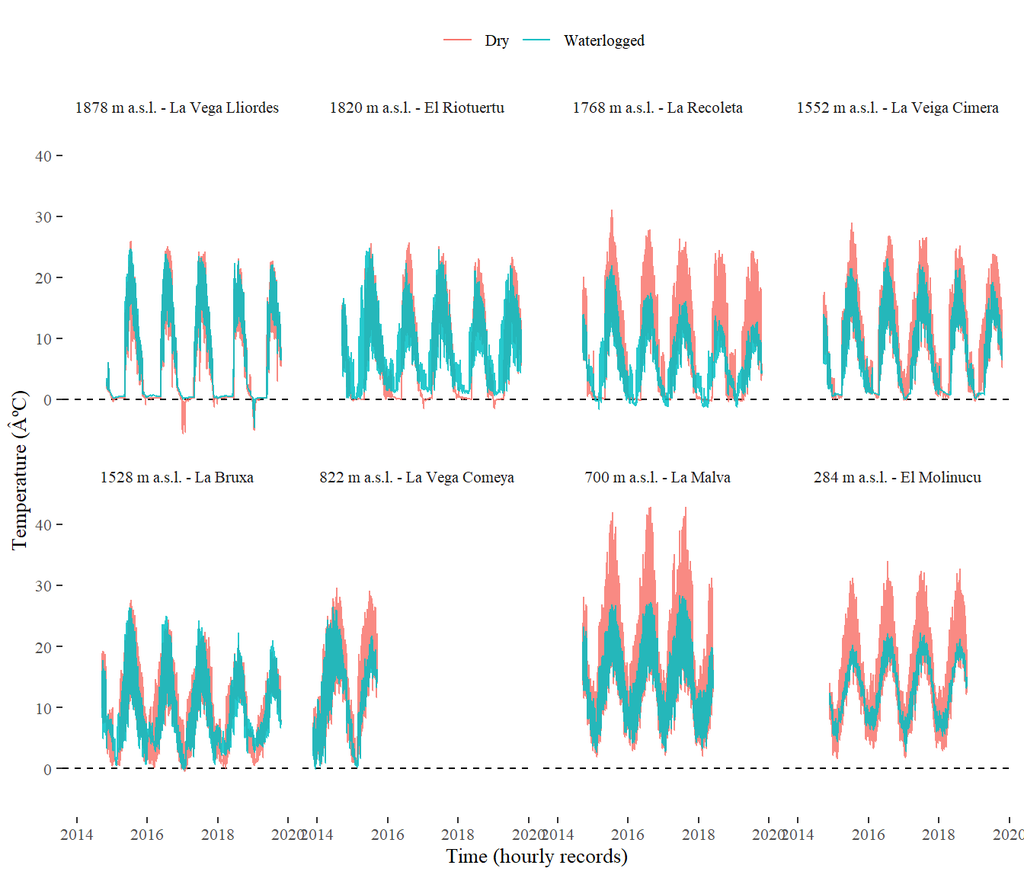

Figure 6.1: Hourly soil temperature records at the mire sites. The blue series was recorded within the mire, in a waterloged area. The red series was recorded in a neighbouring dry area. Dataloggers were buried at 5 cm depth.

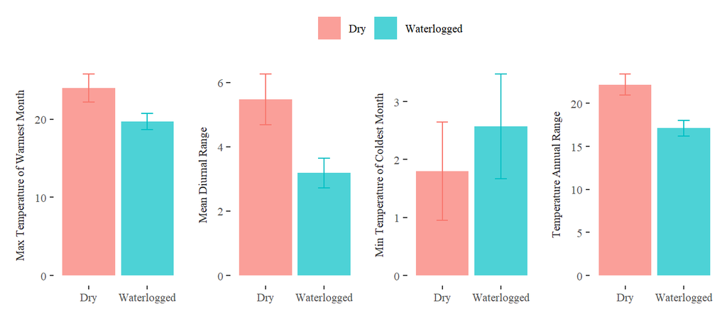

Figure 6.2: Average bioclimatic variables in the dry and waterlogged sites. The bars represent the mean value, and the bars the standard error of 8 records

# References

Bergamini, A., M. Peintinger, S. Fakheran, H. Moradi, B. Schmid, and J. Joshi. 2009. “Loss of Habitat Specialists Despite Conservation Management in Fen Remnants 1995-2006.” Journal Article. *Perspectives in Plant Ecology, Evolution and Systematics* 11 (1): 65–79. https://doi.org/10.1016/j.ppees.2008.10.001.

Breckle, Siegmar-Walter. 2002. *Walter’s Vegetation of the Earth: The Ecological Systems of the Geo-Biosphere*. Book. Berlin - Heidelberg - New York: Springer.

Cornelissen, Johannes H. C., Peter M. Van Bodegom, Rien Aerts, Terry V. Callaghan, Richard S. P. Van Logtestijn, Juha Alatalo, F. Stuart Chapin, et al. 2007. “Global Negative Vegetation Feedback to Climate Warming Responses of Leaf Litter Decomposition Rates in Cold Biomes.” Journal Article. *Ecology Letters* 10 (7): 619–27. https://doi.org/10.1111/j.1461-0248.2007.01051.x.

Dítě, Daniel, Tomáš Peterka, Zuzana Dítětová, Petra Hájková, and Michal Hájek. 2017. “Arcto-Alpine Species at Their Niche Margin: The Western Carpathian Refugia of <i>Juncus Castaneus</I> and <i>J. Triglumis</I> in Slovakia.” Journal Article. *Annales Botanici Fennici* 54 (1–3): 67–82, 16. https://doi.org/10.5735/085.054.0311.

Ellenberg, Heinz. 1988. “Spring Areas and Adjacent Swamps.” Book Section. In, 313–13. Cambridge: Cambridge University Press.

Essl, Franz, Stefan Dullinger, Dietmar Moser, Wolfgang Rabitsch, and Ingrid Kleinbauer. 2012. “Vulnerability of Mires Under Climate Change: Implications for Nature Conservation and Climate Change Adaptation.” Journal Article. *Biodiversity and Conservation* 21: 655–69.

Fernandez-Pascual, Eduardo, Borja Jimenez-Alfaro, Michal Hajek, Tomas E. Diaz, Hugh W. Pritchard, Eduardo Fernández-Pascual, Borja Jiménez-Alfaro, et al. 2015. “Soil Thermal Buffer and Regeneration Niche May Favour Calcareous Fen Resilience to Climate Change.” Journal Article. *Folia Geobotanica* 50 (4): 293–301. https://doi.org/10.1007/s12224-015-9223-y.

Fernández Prieto, José Antonio, María del Carmen Fernández Ordóñez, and Miguel Ángel Collado Prieto. 1985. “Datos Sobre La Vegetación de Las" Turberas de Esfagnos" Galaico-Asturianas Y Orocantábricas.” Journal Article. *Lazaroa* 7: 443–71.

Geiger, Rudolf, Robert H. Aron, and Paul Todhunter. 2009. *The Climate Near the Ground*. Book. Lanham: Rowman & Littlefield.

Grootjans, A. P., E. B. Adema, W. Bleuten, H. Joosten, M. Madaras, and M. Janáková. 2006. “Hydrological Landscape Settings of Base-Rich Fen Mires and Fen Meadows: An Overview.” Journal Article. *Applied Vegetation Science* 9: 175–84. http://search.ebscohost.com/login.aspx?direct=true&db=aph&AN=25691039&lang=es&site=ehost-live.

Hoegh-Guldberg, Ove, Elvira S. Poloczanska, William Skirving, and Sophie Dove. 2017. “Coral Reef Ecosystems Under Climate Change and Ocean Acidification.” Journal Article. *Frontiers in Marine Science* 4 (158). https://doi.org/10.3389/fmars.2017.00158.

Horsák, Michal, Vendula Polášková, Marie Zhai, Jindřiška Bojková, Vít Syrovátka, Vanda Šorfová, Jana Schenková, Marek Polášek, Tomáš Peterka, and Michal Hájek. 2018. “Spring-Fen Habitat Islands in a Warming Climate: Partitioning the Effects of Mesoclimate Air and Water Temperature on Aquatic and Terrestrial Biota.” Journal Article. *Science of the Total Environment* 634: 355–65. https://doi.org/https://doi.org/10.1016/j.scitotenv.2018.03.319.

Hoyos, D de, Jesús Muñoz Fuente, A Negro, Juan José Aldasoro, JC Vega, and Gonzalo Moreno Moral. n.d. “A Survey on Cantabrian Mires (Spain).” Conference Proceedings. In *Anales Del Jardín Botánico de Madrid*, 54:472–89. Real Jardín Botánico.

Huang, Jianping, Haipeng Yu, Xiaodan Guan, Guoyin Wang, and Ruixia Guo. 2016. “Accelerated Dryland Expansion Under Climate Change.” Journal Article. *Nature Climate Change* 6 (2): 166–71. https://doi.org/10.1038/nclimate2837.

Ipcc. 2014. *Climate Change 2014: Synthesis Report. Contribution of Working Groups I, Ii and Iii to the Fifth Assessment Report of the Intergovernmental Panel on Climate Change [Core Writing Team, R.k. Pachauri and L.a. Meyer (Eds.)]*. Book. Geneva: IPCC.

Jiménez-Alfaro, Borja, Tomás Díaz González, and Eduardo Fernández-Pascual. 2011. “Grupos de Vegetación Y Hábitats de Tremedales Neutro-Basófilos En Las Montañas Pirenaico-Cantábricas.” Journal Article. *Acta Botanica Barcinonensia* 53: 47–60.

Jiménez-Alfaro, Borja, Laura García-Calvo, Pedro García, and José Luis Acebes. 2016. “Anticipating Extinctions of Glacial Relict Populations in Mountain Refugia.” Journal Article. *Biological Conservation* 201: 243–51.

Körner, Christian. 2003. *Alpine Plant Life: Functional Plant Ecology of High Mountain Ecosystems*. Book. 2nd ed. Berlin - Heidelberg - New York: Springer.

Körner, Christian, and Jens Paulsen. 2004. “A World-Wide Study of High Altitude Treeline Temperatures.” Journal Article. *Journal of Biogeography* 31: 713–32. [http://10.0.4.87/j.1365-2699.2003.01043.x http://search.ebscohost.com/login.aspx?direct=true&db=aph&AN=12823821&lang=es&site=ehost-live](http://10.0.4.87/j.1365-2699.2003.01043.x%0Ahttp://search.ebscohost.com/login.aspx?direct=true&db=aph&AN=12823821&lang=es&site=ehost-live).

Pearson, Richard G., and Terence P. Dawson. 2005. “Long-Distance Plant Dispersal and Habitat Fragmentation: Identifying Conservation Targets for Spatial Landscape Planning Under Climate Change.” Journal Article. *Biological Conservation* 123 (3): 389–401. https://doi.org/https://doi.org/10.1016/j.biocon.2004.12.006.

Peterka, Tomáš, Michal Hájek, Martin Jiroušek, Borja Jiménez-Alfaro, Liene Aunina, Ariel Bergamini, Daniel Dítě, et al. 2017. “Formalized Classification of European Fen Vegetation at the Alliance Level.” Journal Article. *Applied Vegetation Science* 20 (1): 124–42. https://doi.org/10.1111/avsc.12271.

Raney, PatrickA, JasonD Fridley, and DonaldJ Leopold. 2014. “Characterizing Microclimate and Plant Community Variation in Wetlands.” Journal Article. *Wetlands* 34 (1): 43–53. https://doi.org/10.1007/s13157-013-0481-2.

Raney, Patrick A., Donald J. Leopold, Martin Dovčiak, and Colin M. Beier. 2016. “Hydrologic Position Mediates Sensitivity of Tree Growth to Recent Climate Change: Wetlands as Refugia in a Warmer World.” Journal Article. *Ecological Applications* in press.

Sánchez de Dios, Rut, Marta Benito-Garzón, and Helios Sainz-Ollero. 2009. “Present and Future Extension of the Iberian Submediterranean Territories as Determined from the Distribution of Marcescent Oaks.” Journal Article. *Plant Ecology* 204 (2): 189–205. https://doi.org/10.1007/s11258-009-9584-5.

Schenková, Jana, Vendula Polášková, Martina Bílková, Jindřiška Bojková, Vít Syrovátka, Marek Polášek, and Michal Horsák. n.d. “Climatically Induced Temperature Instability of Groundwater-Dependent Habitats Will Suppress Cold-Adapted Clitellata Species.” Journal Article. *International Review of Hydrobiology* n/a (n/a). https://doi.org/10.1002/iroh.201902006.

Seidl, Rupert, Dominik Thom, Markus Kautz, Dario Martin-Benito, Mikko Peltoniemi, Giorgio Vacchiano, Jan Wild, et al. 2017. “Forest Disturbances Under Climate Change.” Journal Article. *Nature Climate Change* 7 (6): 395–402. https://doi.org/10.1038/nclimate3303.

Storlie, Collin, Andres Merino-Viteri, Ben Phillips, Jeremy VanDerWal, Justin Welbergen, and Stephen Williams. 2014. “Stepping Inside the Niche: Microclimate Data Are Critical for Accurate Assessment of Species’ Vulnerability to Climate Change.” Journal Article. *Biology Letters* 10 (9): 20140576. https://doi.org/doi:10.1098/rsbl.2014.0576.

Wheeler, B. D., and M. C. F. Proctor. 2000. “Ecological Gradients, Subdivisions and Terminology of North-West European Mires.” Journal Article. *Journal of Ecology* 88 (2): 187–203. https://doi.org/10.1046/j.1365-2745.2000.00455.x.